# Rabivy AI Engine - Live Monitoring and Human Feedback

How a real question gets classified automatically, how a rep can flag one that looks wrong, and what shows up on the dashboard

Author

Tilabo Williamson, Caitlin Buenk & Jürgen Becker (Project Lead) - AX Consult Group

Published

2026-08-14

[figure not shown]

Project Overview Evaluation Suite Live Queries and User Feedback Dashboard Write Up Maintenance Dashboard

# Introduction

*AX Consult Group - commercial showcase.*

The Evaluation Suite page covers testing under controlled conditions - a fixed set of 30 questions with a known-correct answer, run the same way every time. This page covers the opposite problem: what happens to a genuinely new question from a real rep, one the system has never seen before, where there’s no stored answer to check it against.

See the Layer 8 summary on the Project Overview page for where this fits in the pipeline.

A live question is any real question a rep types into the chat interface - unlike the 30 fixed questions on the Evaluation Suite page, nobody wrote it in advance and there’s no known-correct answer to check it against.

Every live question gets two layers of scrutiny. Layer 1 runs automatically, on every question, with no human involved. Layer 2 is user feedback - a rep optionally reviewing an answer and leaving a correctness label. Both are covered below.

# Live Query Checks

Every question on the golden 30 was written to exercise a real capability, and `ground_truth.py` can always compute what the correct answer *should* be, live, from the current data - that’s what makes it testable at all.

A real question typed by a rep in the field has neither of those things. Nobody wrote it ahead of time, and there’s no spreadsheet cell or hand-verified fact sitting there to check it against.

So a live question can’t be graded the way a golden-set question can. What it *can* get, automatically, the moment it’s answered, is a check on whether the system behaved the way it’s supposed to - whether a:

- **tool was actually called**,
- **whether retrieval looked confident**,
- **whether the answer cited evidence**,
- **whether the audit step raised a flag.**

That’s the first layer below, and it runs on **every** live question, no human involved.

The second layer only happens when a rep actually looks at an answer and decides to review it - correct, wrong, not sure. That review is optional, and it’s what the user feedback system further below is for.

## Layer 1 - the four automatic gates

Every answer a live question receives passes through the same four checks:

- **Tool grounding** - was a real tool actually called, rather than the model answering from nothing?
- **Retrieval confidence** - did whatever was retrieved come back confident, with no errors or low-confidence flags raised?
- **Source citations included** - did the written answer actually cite something it retrieved, rather than asserting a fact with nothing backing it?
- **Hallucination audit** - did the independent verification pass (the one described on the Overview page’s trust note) come back clean?

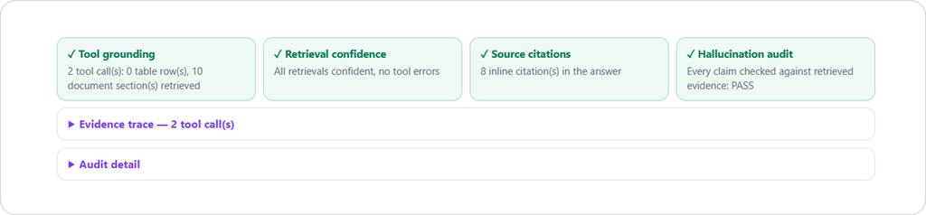

Four Gates

Passing all four gates is not the same as the answer being *correct* - it only means the **process behaved**. That distinction is exactly why this stays a separate, plainer classification from the user feedback one below, rather than being blended into it.

See the figure below for the live-queries decision tree - the four gates and their pass/fail outcomes.

[figure not shown]

Live Queries decision tree

**Green** - System worked. No action needed.

**Amber** - System partially working. Live flag. Potential review/batch review. Track prevalence over time.

**Red** - System not working. Live flag. Block Answer. Review all occurrences. Track prevalence over time.

The four gates don’t all carry the same weight. **Tool grounding**, **retrieval confidence**, and **source citations** are all signals about *how* the answer was produced - worth a caution, but not proof the final answer is wrong. Because the assistant has conversation memory, a live question can legitimately fail all three at once and still be completely fine: a follow-up answered entirely from an earlier answer’s evidence calls no new tool, retrieves nothing new to be confident about, and may not repeat the earlier citation - none of that means anything actually went wrong. All three are Amber for exactly that reason: worth a look, not a confirmed problem.

The **hallucination audit** is different - it’s the one signal about the *answer itself*, checking whether the answer’s claims are actually backed by the evidence it has, fresh or remembered. A written answer with nothing backing it, or one this check actively flags as unsupported, is direct evidence of a bad answer, not just a process caution. That’s why it’s the only gate that’s Red - and the only one that actually blocks the answer from reaching the rep (see the trust note on the Project Overview page for exactly how).

## Layer 2 - User feedback, when a rep flags something

User feedback means a structured, human correctness signal captured on a real answer. It’s a review a rep can leave on any answer, walking through a short, fixed set of prompts, that produces a genuine correctness label.

The first thing checked, automatically rather than asked, is whether the engine actually **surfaced an answer at all**, or **declined** (no tool was called - an honest “I don’t know”). That single fact decides which questions the rep sees next, because a decline has no evidence to judge and shouldn’t be asked an evidence question at all.

**If the engine surfaced an answer:**

1. The rep rates it - **Correct**, **Partially correct**, **Incorrect**, or **Vague**.
2. For anything other than Vague, the rep is asked whether the evidence actually backing the answer was right - **Yes**, **No**, or **Not sure**.
3. If the evidence was confirmed right, the rep picks which specific chunk it came from (or says they’re not sure which one).

**If the engine declined:**

The rep is asked a different, simpler question instead - **was declining the right call?** - Correct, Incorrect, or Not sure. There’s no evidence to weigh on a non-answer, so the flow doesn’t ask for any.

Depending on the combination of answers, a review lands on one of a fixed set of outcomes:

| Outcome | Meaning | Colour |
| --- | --- | --- |
| Correct answer | Surfaced an answer, rated correct, evidence confirmed | Green |
| Correctly rejected | Declined, and declining was the right call | Green |
| Correct anyway | Surfaced an answer, rated correct, but the evidence wasn’t actually right | Amber |
| Retrieval fail | Declined, but declining was the wrong call | Amber |
| Vague / non-answer | Rated vague - didn’t really answer the question | Amber |
| Synthesis issue | Surfaced an answer, rated wrong, but the evidence itself was right | Red |
| Hallucination | Surfaced an answer, rated wrong, and the evidence wasn’t right either | Red |
| Flagged for review | Rep wasn’t sure on the evidence question - left unresolved rather than guessed | Grey |

See the figure below for the full user feedback prompt flow, from surfaced-or-declined down to each outcome above.

[figure not shown]

User feedback decision tree

Both layers above feed into one place: the results are collected, stored, and displayed on a dashboard. See the Maintenance Dashboard page for the full explanation.

### What a user review is (and isn’t)

- **Review is a single question and answer, not a conversation.** A rep flags one answer, works through a short set of prompts, and that’s the end of it - not an ongoing back-and-forth or a write-up.
- **Review is optional and rep-initiated.** A rep chooses when something looks worth flagging, so the User Feedback tab reflects whatever reps happened to notice - not a random or complete sample of everything the system has answered.

## Agent Batch Review

A third, separate check sits alongside the two layers above: another AI agent that batch-reviews a sample of live queries. The agent is checked against an entrance exam before it’s trusted on anything real.

Before it’s allowed to review anything real, the agent has to pass an entrance exam - scoring at least 90% on a set of questions with a known correct answer. Once it clears that bar, it pulls a random sample of live queries that came back **Green or Amber** - Red ones are already flagged for mandatory human review, so there’s nothing extra to check there - and reruns the audit check on each one, blind, to confirm it finds the same thing the automatic gates did.

The same batch can also get reviewed by a human on a separate page, blind to what the agent decided, and the two sets of answers can be compared to see how closely they agree.

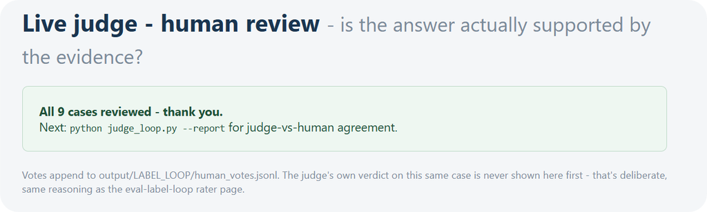

Human Review

It’s a short, hand-run loop (`judge_loop.py` + `human_review_ui.py`) - its results already show up on the Maintenance Dashboard page, as a “Batch review” view under the Live Queries tab.

*AX Consult Group. Rabivy is used here as a commercial analytics showcase and is not intended for clinical use.*

[View the project on GitHub](https://github.com/AX-Consult-Group/medical-Rabivy-AI-engine)

Project Overview Evaluation Suite Live Queries and User Feedback Dashboard Write Up Maintenance Dashboard